# Total Survey Error

## Surveys

- Surveys are systematic efforts to gather quantitative information about a larger population.
- Most surveys measure population characteristics by *sampling* from a population.

## Surveys

In this class, we’re typically looking at surveys that measure characteristics of people, but keep in mind that many of these same principles apply to other things.

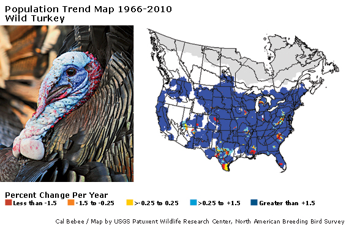

A result from the North American Breeding Bird Survey

## Surveys and errors

- Errors in this context refer to differences between what we *intend* to measure and what we actually measure.
- Errors can be random or systematic, and they can come from both the measurement process and the process of representing a population.

## Polling misses

Why did polls miss Brexit?

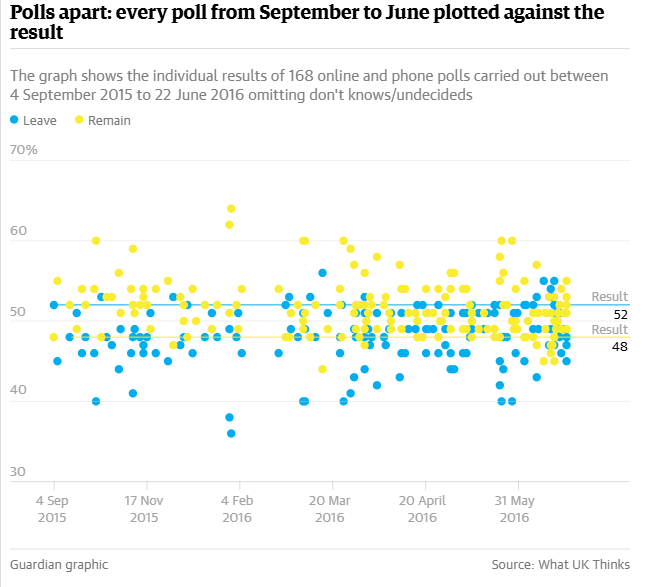

Why did they whiff on Trump in 2016?

[figure not shown]

## Causes of polling error

What might cause a poll to give an inaccurate result?

# Total Survey Error

[figure not shown]

Adapted from Groves et al. (2009)

## Total Survey Error

Representation how well does our sample match our target population?

[figure not shown]

## Total Survey Error

Measurement how well does our instrument quantify the thing we’re interested in?

[figure not shown]

# Constructs and Specification Error

## Constructs

- A construct is the thing we’re trying to measure.
- I might measure unemployment, blood pressure, life-satisfaction or intelligence, but I need to define them and then measure them.

## Constructs

- Validity refers to how well a measurement actually captures the construct we care about.
- Specification Error refers to error introduced when there’s a mismatch between the concept and the tool we’re using to measure it.

## Constructs

Even simple constructs like employment/unemployment can be difficult to define systematically

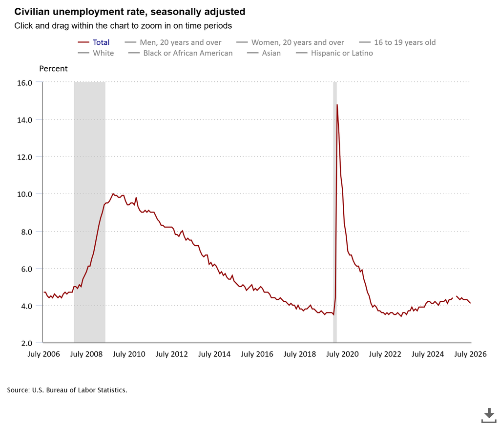

## Constructs

Measuring unemployment:

- Are retirees “unemployed”?
- Does part time employment count as being employed? Volunteer work?
- Are seasonal workers unemployed for half the year?

## Constructs

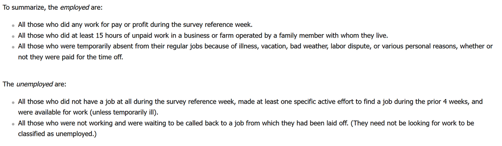

From: https://www.bls.gov/cps/cps_htgm.htm#unemployed

[figure not shown]

## Constructs

Nuanced concepts like “life satisfaction” can be even more tricky:

- Is “life satisfaction” entirely subjective?
- Is it a stable outlook or is it more like a “mood” that can change quickly?
- Is it about comparing yourself to others or is relative to your personal goals?

## Latent Constructs

- Even where we can agree on a conceptual definition, many complex constructs are latent, meaning we can’t measure them directly.
- At best, we might be able to observe the symptoms of life satisfaction, but not the thing itself.

## Latent Constructs

[figure not shown]

# Latent Constructs

[figure not shown]

## Latent Constructs and Validity

What might go wrong if I used “smiling” to measure “life satisfaction”?

# Measurement Error

## Measurement Error

Measurement errors are a gap between the ideal measurement and the measure we actually obtain.

### Measurement error

- Instrument malfunction
- Distractions
- Language barriers
- Observer effects

### Measurement error: Example

- “White coat syndrome” is when someone experiences high blood pressure at the doctor’s office but normal blood pressure at home.

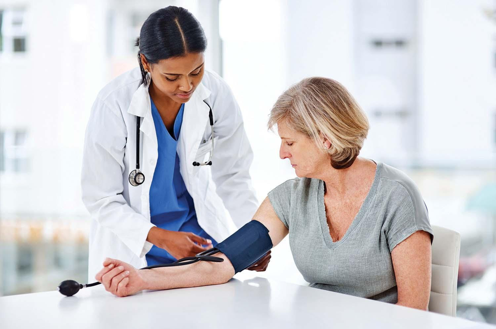

### Measurement error

In the “life satisfaction” case:

- Maybe respondents don’t understand one of my survey questions.
- Maybe respondents get distracted by a loud noise or poor connection.
- Maybe respondents are hesitant to admit their real feelings to a stranger.

### Measurement error vs. Specification Error

- This distinction is hazy in practice, but conceptually: validity problems would be a source of error even if our measurement process worked exactly as intended.
- If I ask “who do you intend to vote for in the upcoming election?”, even respondents who understand the question and answer truthfully might just change their minds before the election.

# Processing Error

## Processing Error

Processing errors occur in the translation from data to analysis: data-entry mistakes, miscalculations, programming errors etc.

### Processing errors: Example

Open ended questions (like “what is the most important problem facing the country”) are usually manually grouped into a smaller set of categories.

[figure not shown]

… But this re-interpretation introduces new potential for errors.

# Bias and Variability

## Bias and Variability

- Many of the statistics we’ll talk about in this class will assume some notion of “what happens in repeated trials?”
- Conceptually, each measure $y_i$ is thought of as a single realization of an infinite number of potential measurements $y_{it}$

## Bias vs. Variability

- Bias and variability refer to two different ways that our expected value ($E_t$) of $y_{it}$ over many trials would differ from $Y_i$:

$$\mathbb{E}_t(y_{it}) - Y_i$$

## Bias vs. Variability

If error is random, then:

$$\mathbb{E}_t(y_{it}) = Y_i$$

If error systematic, then:

$$\mathbb{E}_t(y_{it}) \neq Y_i$$

## Bias vs. Variability in measurement error

Random

- Distractions
- Fleeting positive or negative moods
- Interviewer mistakes

Systematic

- Social desirability bias
- Observer effects
- Language barriers

# John Zaller and models of responding

## Survey responses and Zaller

Key Questions:

- What are we actually hoping to measure when we measure “public opinion”?
- Is public opinion a coherent thing? Do surveys miss important dimensions of it?

## Survey Responses

## Two views of public opinion

Two views are worth reviewing for context:

- A more pessimistic view: “non-attitudes”
- A more optimistic view: measurement error.

## The American Voter

Systematic research on public opinion and vote choice in the 1960s turns up some troubling stuff.

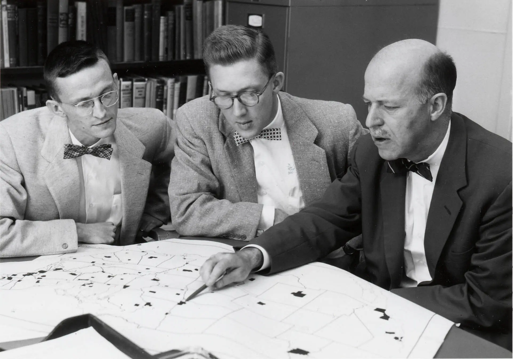

Phillip Converse, Angus Campbell and Warren Miller

### Low conceptualization

- Very few respondents express systematic reasons for their party preferences.

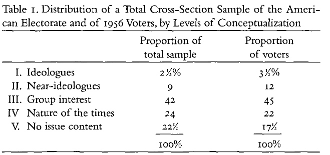

(Converse 2006)

### Low Constraint

- Few people exhibit **constraint** or a systematic worldview. Their attitudes across related issue-areas are only weakly correlated.

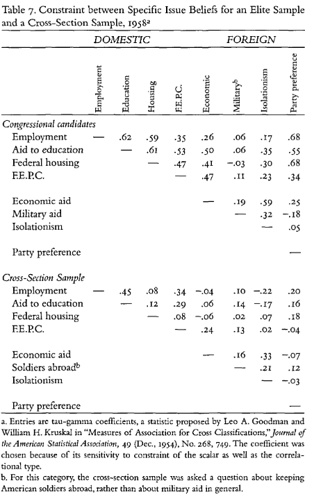

(Converse 2006)

### Issue instability

- Other than party ID, most people’s views are not stable over time, even on important issues.

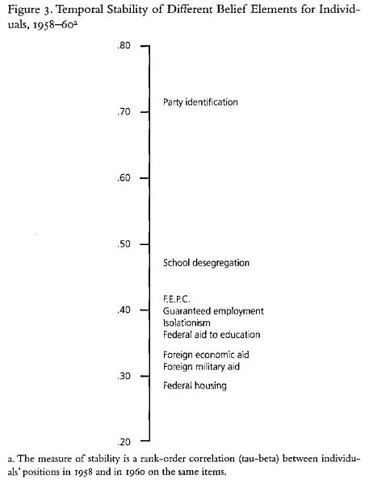

(Converse 2006)

### Wording effects

- Seemingly minor changes to question wording have big effects on preferences.

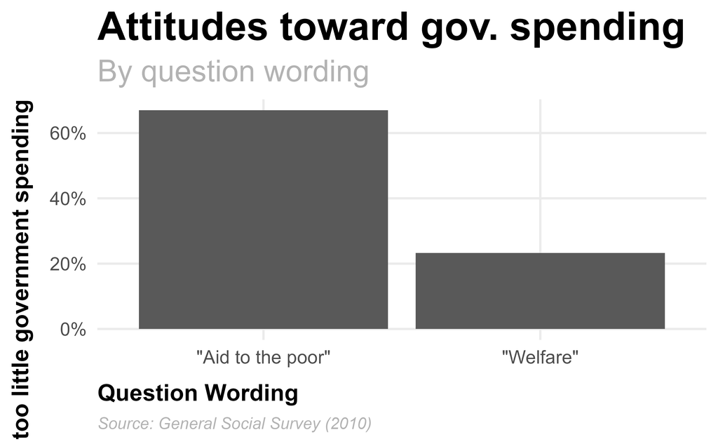

## Pessimistic interpretation: Non-attitudes

For Converse, many survey responses represent **non-attitudes**:

> “Large portions of an electorate simply do not have meaningful beliefs”

## Pessimistic interpretation: Non-attitudes

- Surveys purportedly measure public opinion, but many respondents don’t have opinions to measure.
- Note that this is mostly a criticism of the construct validity of survey responses.

## A more optimistic interpretation: Measurement Error

- An alternative explanation for these results is measurement error. What if our questions are just confusing?
- Chris Achen notes that there was response instability even on non-political questions like “how often do you attend church?” (Achen 1975)

## A more optimistic interpretation: Measurement Error

- If random measurement error is a problem, then averaging multiple measurements should improve it: random errors will cancel out when we get more measurements ($\mathbb{E}_t(y_{it}) = Y_i$)

## A more optimistic interpretation: Measurement Error

- Response instability decreases (but doesn’t disappear) when we ask more questions. (Ansolabehere et al. 2008)

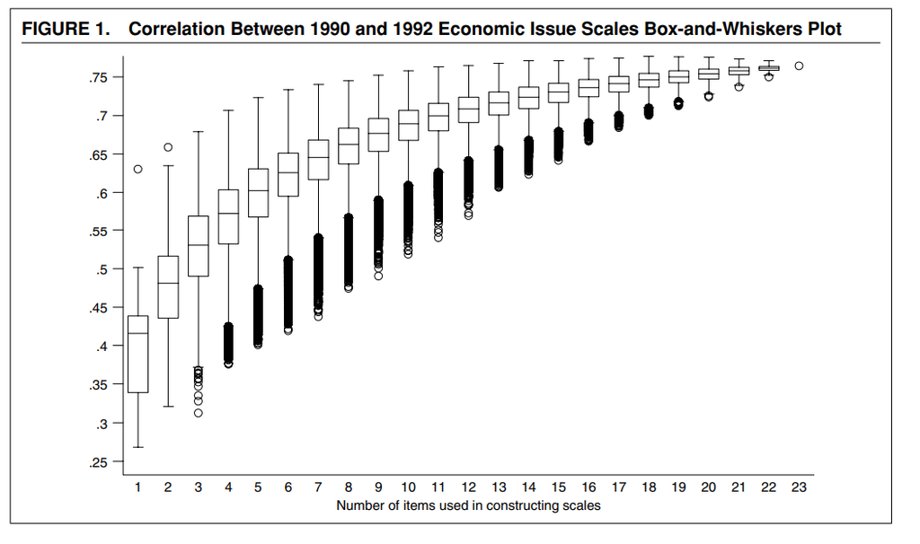

## Survey responses and Zaller

- Where does Zaller land on this debate?
- If he’s right, what can be done to improve the results of public opinion surveys?

# References

[figure not shown]

Achen, Christopher H. 1975. “Mass Political Attitudes and the Survey Response.” *American Political Science Review* 69 (4): 1218–31.

Ansolabehere, Stephen, Jonathan Rodden, and James M Snyder Jr. 2008. “The Strength of Issues: Using Multiple Measures to Gauge Preference Stability, Ideological Constraint, and Issue Voting.” *American Political Science Review* 102 (2): 215–32.

Converse, Philip E. 2006. “The Nature of Belief Systems in Mass Publics (1964).” *Critical Review* 18 (1-3): 1–74.

Groves, Robert M., Floyd J. Fowler, Mick P. Couper, James M. Lepkowski, Eleanor Singer, and Roger Tourangeau. 2009. *Survey Methodology*. 2nd ed. John Wiley & Sons.